# TimeSeries_Predict_Demand_Dataset

Name : Truptirani Mahapatra

Introduction: Given is a dataset in which we have to analyze and predict the demand of different products over different cities.

```python
# We need to import Libraries to perform different functions. Numpy is a library for the Python programming language, to perform high-level mathematical function
# Pandas is Python library that has functions for analyzing, cleaning, exploring, and manipulating data.
# Matplotlib and seaborn are  comprehensive library for creating statical,  and interactive visualizations in Python.
#The datetime module supplies classes for manipulating dates and times.
#The warnings filter controls whether warnings are ignored, displayed, or turned into errors
import numpy as np
import pandas as pd
import matplotlib.pyplot as plt
%matplotlib inline
import seaborn as sns
from datetime import datetime
import warnings
warnings.filterwarnings('ignore')
```

```python
originalTrain = pd.read_csv("RaniPython/train.csv")
originalTest = pd.read_csv("RaniPython/test.csv")
```

```python
originalTrain.head()
```

|  | id | date | city | lat | long | pop | shop | brand | container | capacity | price | quantity |
| --- | --- | --- | --- | --- | --- | --- | --- | --- | --- | --- | --- | --- |
| 0 | 0.0 | 31/01/12 | Athens | 37.97945 | 23.71622 | 672130.0 | shop_1 | kinder-cola | glass | 500ml | 0.96 | 13280.0 |
| 1 | 1.0 | 31/01/12 | Athens | 37.97945 | 23.71622 | 672130.0 | shop_1 | kinder-cola | plastic | 1.5lt | 2.86 | 6727.0 |
| 2 | 2.0 | 31/01/12 | Athens | 37.97945 | 23.71622 | 672130.0 | shop_1 | kinder-cola | can | 330ml | 0.87 | 9848.0 |
| 3 | 3.0 | 31/01/12 | Athens | 37.97945 | 23.71622 | 672130.0 | shop_1 | adult-cola | glass | 500ml | 1.00 | 20050.0 |
| 4 | 4.0 | 31/01/12 | Athens | 37.97945 | 23.71622 | 672130.0 | shop_1 | adult-cola | can | 330ml | 0.39 | 25696.0 |

```python
originalTrain.shape
```

```
(7560, 12)
```

```python
originalTrain.describe()
```

|  | id | lat | long | pop | price | quantity |
| --- | --- | --- | --- | --- | --- | --- |
| count | 6480.000000 | 6429.000000 | 6434.000000 | 6480.000000 | 6480.000000 | 6480.000000 |
| mean | 3239.500000 | 38.301238 | 23.270246 | 355141.416667 | 1.188981 | 29431.855093 |
| std | 1870.759204 | 1.649771 | 1.086960 | 232828.796289 | 0.814567 | 17901.328301 |
| min | 0.000000 | 35.327870 | 21.734440 | 134219.000000 | 0.110000 | 2953.000000 |
| 25% | 1619.750000 | 37.962450 | 22.417610 | 141439.750000 | 0.610000 | 16441.750000 |
| 50% | 3239.500000 | 38.244440 | 22.930860 | 257501.500000 | 0.920000 | 25184.000000 |
| 75% | 4859.250000 | 39.636890 | 23.716220 | 665871.000000 | 1.500000 | 37866.000000 |
| max | 6479.000000 | 40.643610 | 25.143410 | 672130.000000 | 4.540000 | 145287.000000 |

```python
originalTrain.info()
```

```
<class 'pandas.core.frame.DataFrame'>
RangeIndex: 7560 entries, 0 to 7559
Data columns (total 12 columns):
 #   Column     Non-Null Count  Dtype
---  ------     --------------  -----
 0   id         6480 non-null   float64
 1   date       6480 non-null   object
 2   city       6480 non-null   object
 3   lat        6429 non-null   float64
 4   long       6434 non-null   float64
 5   pop        6480 non-null   float64
 6   shop       6480 non-null   object
 7   brand      6480 non-null   object
 8   container  6464 non-null   object
 9   capacity   6465 non-null   object
 10  price      6480 non-null   float64
 11  quantity   6480 non-null   float64
dtypes: float64(6), object(6)
memory usage: 708.9+ KB
```

```python
originalTrain.isnull().sum()
```

```
id           1080
date         1080
city         1080
lat          1131
long         1126
pop          1080
shop         1080
brand        1080
container    1096
capacity     1095
price        1080
quantity     1080
dtype: int64
```

```python
originalTrain['city'].value_counts()
```

```
Athens          2160
Larisa          1080
Thessaloniki    1080
Patra           1080
Irakleion       1080
Name: city, dtype: int64
```

```python
originalTrain['shop'].value_counts()
```

```
shop_5    1080
shop_2    1080
shop_3    1080
shop_4    1080
shop_1    1080
shop_6    1080
Name: shop, dtype: int64
```

```python
originalTrain['brand'].unique()
```

```
array(['kinder-cola', 'adult-cola', 'orange-power', 'gazoza',
       'lemon-boost', nan], dtype=object)
```

```python
originalTrain['container'].nunique()
```

```
3
```

```python
originalTrain['container'].unique()
```

```
array(['glass', 'plastic', 'can', nan], dtype=object)
```

# Description:

[output not shown]

```python
originalTest.head()
```

|  | id | date | city | lat | long | pop | shop | brand | container | capacity | price | quantity |
| --- | --- | --- | --- | --- | --- | --- | --- | --- | --- | --- | --- | --- |
| 0 | 6480 | 31/01/18 | Athens | 37.97945 | 23.71622 | 664046 | shop_1 | kinder-cola | plastic | 1.5lt | 3.10 | 7056 |
| 1 | 6481 | 31/01/18 | Athens | 37.97945 | 23.71622 | 664046 | shop_1 | kinder-cola | can | 330ml | 0.85 | 12490 |
| 2 | 6482 | 31/01/18 | Athens | 37.97945 | 23.71622 | 664046 | shop_1 | adult-cola | glass | 500ml | 0.83 | 26640 |
| 3 | 6483 | 31/01/18 | Athens | 37.97945 | 23.71622 | 664046 | shop_1 | orange-power | glass | 500ml | 0.54 | 41892 |
| 4 | 6484 | 31/01/18 | Athens | 37.97945 | 23.71622 | 664046 | shop_1 | orange-power | plastic | 1.5lt | 0.83 | 22923 |

```python
originalTest.shape
```

```
(1080, 12)
```

```python
originalTest.describe()
```

|  | id | lat | long | pop | price | quantity |
| --- | --- | --- | --- | --- | --- | --- |
| count | 1080.00000 | 1072.000000 | 1067.000000 | 1080.000000 | 1080.000000 | 1080.000000 |
| mean | 7019.50000 | 38.298228 | 23.269862 | 355370.166667 | 1.238454 | 29360.875926 |
| std | 311.91345 | 1.655656 | 1.088977 | 230207.452873 | 0.829449 | 16182.538761 |
| min | 6480.00000 | 35.327870 | 21.734440 | 137154.000000 | 0.230000 | 3523.000000 |
| 25% | 6749.75000 | 37.962450 | 22.417610 | 144651.000000 | 0.650000 | 17229.750000 |
| 50% | 7019.50000 | 38.244440 | 22.930860 | 261162.000000 | 0.980000 | 26010.500000 |
| 75% | 7289.25000 | 39.636890 | 23.716220 | 664046.000000 | 1.555000 | 37421.750000 |
| max | 7559.00000 | 40.643610 | 25.143410 | 664046.000000 | 4.790000 | 116612.000000 |

```python
originalTest.info()
```

```
<class 'pandas.core.frame.DataFrame'>
RangeIndex: 1080 entries, 0 to 1079
Data columns (total 12 columns):
 #   Column     Non-Null Count  Dtype
---  ------     --------------  -----
 0   id         1080 non-null   int64
 1   date       1080 non-null   object
 2   city       1080 non-null   object
 3   lat        1072 non-null   float64
 4   long       1067 non-null   float64
 5   pop        1080 non-null   int64
 6   shop       1080 non-null   object
 7   brand      1080 non-null   object
 8   container  1077 non-null   object
 9   capacity   1076 non-null   object
 10  price      1080 non-null   float64
 11  quantity   1080 non-null   int64
dtypes: float64(3), int64(3), object(6)
memory usage: 101.4+ KB
```

```python
originalTest.isnull().sum()
```

```
id            0
date          0
city          0
lat           8
long         13
pop           0
shop          0
brand         0
container     3
capacity      4
price         0
quantity      0
dtype: int64
```

# Description of test data

The test data here has 1080 rows and 12 columns. It also contain null values in columns lat,long,container and capacity. The distribution of train-test data: percentage of train data in the dataset is 7560/(7560+1080)*100=87.5% and  
percentage of test data in the dataset is 100-87.5=12.5%

```python
#Handling Null Values
```

```python
originalTrain.tail(20)
```

|  | id | date | city | lat | long | pop | shop | brand | container | capacity | price | quantity |
| --- | --- | --- | --- | --- | --- | --- | --- | --- | --- | --- | --- | --- |
| 7540 | NaN | NaN | NaN | NaN | NaN | NaN | NaN | NaN | NaN | NaN | NaN | NaN |
| 7541 | NaN | NaN | NaN | NaN | NaN | NaN | NaN | NaN | NaN | NaN | NaN | NaN |
| 7542 | NaN | NaN | NaN | NaN | NaN | NaN | NaN | NaN | NaN | NaN | NaN | NaN |
| 7543 | NaN | NaN | NaN | NaN | NaN | NaN | NaN | NaN | NaN | NaN | NaN | NaN |
| 7544 | NaN | NaN | NaN | NaN | NaN | NaN | NaN | NaN | NaN | NaN | NaN | NaN |
| 7545 | NaN | NaN | NaN | NaN | NaN | NaN | NaN | NaN | NaN | NaN | NaN | NaN |
| 7546 | NaN | NaN | NaN | NaN | NaN | NaN | NaN | NaN | NaN | NaN | NaN | NaN |
| 7547 | NaN | NaN | NaN | NaN | NaN | NaN | NaN | NaN | NaN | NaN | NaN | NaN |
| 7548 | NaN | NaN | NaN | NaN | NaN | NaN | NaN | NaN | NaN | NaN | NaN | NaN |
| 7549 | NaN | NaN | NaN | NaN | NaN | NaN | NaN | NaN | NaN | NaN | NaN | NaN |
| 7550 | NaN | NaN | NaN | NaN | NaN | NaN | NaN | NaN | NaN | NaN | NaN | NaN |
| 7551 | NaN | NaN | NaN | NaN | NaN | NaN | NaN | NaN | NaN | NaN | NaN | NaN |
| 7552 | NaN | NaN | NaN | NaN | NaN | NaN | NaN | NaN | NaN | NaN | NaN | NaN |
| 7553 | NaN | NaN | NaN | NaN | NaN | NaN | NaN | NaN | NaN | NaN | NaN | NaN |
| 7554 | NaN | NaN | NaN | NaN | NaN | NaN | NaN | NaN | NaN | NaN | NaN | NaN |
| 7555 | NaN | NaN | NaN | NaN | NaN | NaN | NaN | NaN | NaN | NaN | NaN | NaN |
| 7556 | NaN | NaN | NaN | NaN | NaN | NaN | NaN | NaN | NaN | NaN | NaN | NaN |
| 7557 | NaN | NaN | NaN | NaN | NaN | NaN | NaN | NaN | NaN | NaN | NaN | NaN |
| 7558 | NaN | NaN | NaN | NaN | NaN | NaN | NaN | NaN | NaN | NaN | NaN | NaN |
| 7559 | NaN | NaN | NaN | NaN | NaN | NaN | NaN | NaN | NaN | NaN | NaN | NaN |

```python
originalTrain[6479:]
```

|  | id | date | city | lat | long | pop | shop | brand | container | capacity | price | quantity |
| --- | --- | --- | --- | --- | --- | --- | --- | --- | --- | --- | --- | --- |
| 6479 | 6479.0 | 31/12/17 | Thessaloniki | 40.64361 | 22.93086 | 353001.0 | shop_4 | adult-cola | glass | 500ml | 1.16 | 30413.0 |
| 6480 | NaN | NaN | NaN | NaN | NaN | NaN | NaN | NaN | NaN | NaN | NaN | NaN |
| 6481 | NaN | NaN | NaN | NaN | NaN | NaN | NaN | NaN | NaN | NaN | NaN | NaN |
| 6482 | NaN | NaN | NaN | NaN | NaN | NaN | NaN | NaN | NaN | NaN | NaN | NaN |
| 6483 | NaN | NaN | NaN | NaN | NaN | NaN | NaN | NaN | NaN | NaN | NaN | NaN |
| ... | ... | ... | ... | ... | ... | ... | ... | ... | ... | ... | ... | ... |
| 7555 | NaN | NaN | NaN | NaN | NaN | NaN | NaN | NaN | NaN | NaN | NaN | NaN |
| 7556 | NaN | NaN | NaN | NaN | NaN | NaN | NaN | NaN | NaN | NaN | NaN | NaN |
| 7557 | NaN | NaN | NaN | NaN | NaN | NaN | NaN | NaN | NaN | NaN | NaN | NaN |
| 7558 | NaN | NaN | NaN | NaN | NaN | NaN | NaN | NaN | NaN | NaN | NaN | NaN |
| 7559 | NaN | NaN | NaN | NaN | NaN | NaN | NaN | NaN | NaN | NaN | NaN | NaN |

1081 rows × 12 columns

Here we can see from id no.6480 all the values of the column are nan, hence we can drop the nan values from the dataset.

```python
originalTrain=originalTrain.dropna()
```

```python
originalTest.dropna()
```

|  | id | date | city | lat | long | pop | shop | brand | container | capacity | price | quantity |
| --- | --- | --- | --- | --- | --- | --- | --- | --- | --- | --- | --- | --- |
| 0 | 6480 | 31/01/18 | Athens | 37.97945 | 23.71622 | 664046 | shop_1 | kinder-cola | plastic | 1.5lt | 3.10 | 7056 |
| 1 | 6481 | 31/01/18 | Athens | 37.97945 | 23.71622 | 664046 | shop_1 | kinder-cola | can | 330ml | 0.85 | 12490 |
| 2 | 6482 | 31/01/18 | Athens | 37.97945 | 23.71622 | 664046 | shop_1 | adult-cola | glass | 500ml | 0.83 | 26640 |
| 3 | 6483 | 31/01/18 | Athens | 37.97945 | 23.71622 | 664046 | shop_1 | orange-power | glass | 500ml | 0.54 | 41892 |
| 4 | 6484 | 31/01/18 | Athens | 37.97945 | 23.71622 | 664046 | shop_1 | orange-power | plastic | 1.5lt | 0.83 | 22923 |
| ... | ... | ... | ... | ... | ... | ... | ... | ... | ... | ... | ... | ... |
| 1075 | 7555 | 31/12/18 | Athens | 37.97945 | 23.71622 | 664046 | shop_1 | kinder-cola | plastic | 1.5lt | 2.52 | 13760 |
| 1076 | 7556 | 31/12/18 | Athens | 37.97945 | 23.71622 | 664046 | shop_1 | orange-power | plastic | 1.5lt | 2.18 | 16309 |
| 1077 | 7557 | 31/12/18 | Patra | 38.24444 | 21.73444 | 168034 | shop_6 | kinder-cola | can | 330ml | 0.85 | 24378 |
| 1078 | 7558 | 31/12/18 | Thessaloniki | 40.64361 | 22.93086 | 354290 | shop_4 | adult-cola | plastic | 1.5lt | 2.17 | 20691 |
| 1079 | 7559 | 31/12/18 | Irakleion | 35.32787 | 25.14341 | 137154 | shop_2 | adult-cola | glass | 500ml | 1.26 | 24615 |

1058 rows × 12 columns

After removing null values the shape of originaltrain set is 6376 rows × 12 columns and original test set is 1058 rows × 12 columns

```python
#We can see here the id column has no use in future analysis so we can drop it.
train_data = originalTrain.copy()
test_data = originalTest.copy()

#Dropping unnecessary Id column.

train_data.drop('id', axis=1, inplace=True)
test_data.drop('id', axis=1, inplace=True)
```

```python
originalTrain.head()
```

|  | id | date | city | lat | long | pop | shop | brand | container | capacity | price | quantity |
| --- | --- | --- | --- | --- | --- | --- | --- | --- | --- | --- | --- | --- |
| 0 | 0.0 | 31/01/12 | Athens | 37.97945 | 23.71622 | 672130.0 | shop_1 | kinder-cola | glass | 500ml | 0.96 | 13280.0 |
| 1 | 1.0 | 31/01/12 | Athens | 37.97945 | 23.71622 | 672130.0 | shop_1 | kinder-cola | plastic | 1.5lt | 2.86 | 6727.0 |
| 2 | 2.0 | 31/01/12 | Athens | 37.97945 | 23.71622 | 672130.0 | shop_1 | kinder-cola | can | 330ml | 0.87 | 9848.0 |
| 3 | 3.0 | 31/01/12 | Athens | 37.97945 | 23.71622 | 672130.0 | shop_1 | adult-cola | glass | 500ml | 1.00 | 20050.0 |
| 4 | 4.0 | 31/01/12 | Athens | 37.97945 | 23.71622 | 672130.0 | shop_1 | adult-cola | can | 330ml | 0.39 | 25696.0 |

# Explaratory Data Analysis

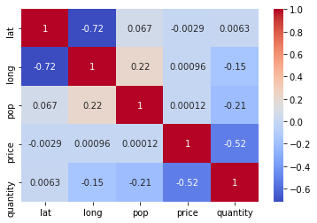

```python
sns.heatmap(train_data.corr(),annot=True,cmap='coolwarm')
```

Through the heatmap we can conclude that as price and quantity are negatively corelated to eachother, as the price increases quantity tends to decrease.

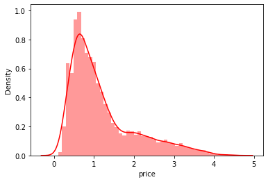

```python
sns.distplot(train_data['price'],color='red')
```

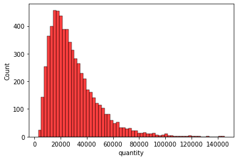

```python
sns.histplot(train_data['quantity'],color='red')
```

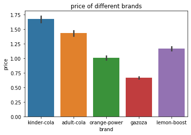

```python
sns.barplot(x=train_data['brand'], y=train_data['price'])
plt.title('price of different brands')
```

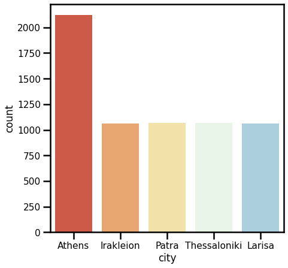

```python
sns.set_context("poster", font_scale=.7)
plt.figure(figsize=(7,7))
sns.set_palette('RdYlBu')
sns.countplot(train_data['city'])
```

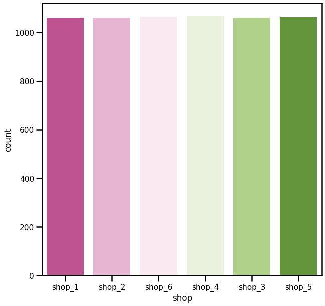

```python
sns.set_palette('PiYG')
plt.figure(figsize=(10,10))
sns.set_context("poster", font_scale=0.7)
sns.countplot(train_data['shop'])
```

# Time Series Analysis

```python
#IN this dataset we are going to predict the demand using time series Analysis. Hence we are going to take the date
#column as the index column and drop other columns keeping the Quantity column intact
```

```python
train_data.set_index('date',inplace=True)
train_data.index
```

```
Index(['31/01/12', '31/01/12', '31/01/12', '31/01/12', '31/01/12', '31/01/12',
       '31/01/12', '31/01/12', '31/01/12', '31/01/12',
       ...
       '31/12/17', '31/12/17', '31/12/17', '31/12/17', '31/12/17', '31/12/17',
       '31/12/17', '31/12/17', '31/12/17', '31/12/17'],
      dtype='object', name='date', length=6376)
```

```python
train_data.head()
```

| date | city | lat | long | pop | shop | brand | container | capacity | price | quantity |
| --- | --- | --- | --- | --- | --- | --- | --- | --- | --- | --- |
| 31/01/12 | Athens | 37.97945 | 23.71622 | 672130.0 | shop_1 | kinder-cola | glass | 500ml | 0.96 | 13280.0 |
| 31/01/12 | Athens | 37.97945 | 23.71622 | 672130.0 | shop_1 | kinder-cola | plastic | 1.5lt | 2.86 | 6727.0 |
| 31/01/12 | Athens | 37.97945 | 23.71622 | 672130.0 | shop_1 | kinder-cola | can | 330ml | 0.87 | 9848.0 |
| 31/01/12 | Athens | 37.97945 | 23.71622 | 672130.0 | shop_1 | adult-cola | glass | 500ml | 1.00 | 20050.0 |
| 31/01/12 | Athens | 37.97945 | 23.71622 | 672130.0 | shop_1 | adult-cola | can | 330ml | 0.39 | 25696.0 |

```python
train_data=train_data.drop(columns=['city','lat','long','pop','shop','brand','container','capacity','price'])
```

```python
train_data.tail()
```

| date | quantity |
| --- | --- |
| 31/12/17 | 33201.0 |
| 31/12/17 | 46971.0 |
| 31/12/17 | 47708.0 |
| 31/12/17 | 27115.0 |
| 31/12/17 | 30413.0 |

```python
train_data.shape
```

```
(6376, 1)
```

```python
train_data.describe()
```

|  | quantity |
| --- | --- |
| count | 6376.000000 |
| mean | 29416.483061 |
| std | 17891.264214 |
| min | 2953.000000 |
| 25% | 16439.750000 |
| 50% | 25180.000000 |
| 75% | 37804.000000 |
| max | 145287.000000 |

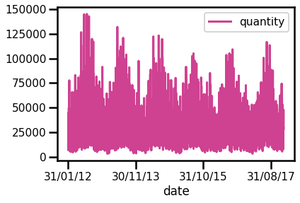

```python
train_data.plot()
```

*Lets us now check the stationarity of data using Dickey Fuller Test as the trends or seasonality in the dataset affects the data* Here we need to take Null Hypothesis in ADF test is the Time Series is non-Stationary and Aternate Hypothesis as dataset is stationary *If the ADF Statistic < Critical Value - Reject the Null Hypothesis* If the ADF Statistic > Critical Value - Failed to Reject the Null Hypothesis

```python
### Testing For Stationarity

from statsmodels.tsa.stattools import adfuller
```

```python
result=adfuller(train_data['quantity'])
```

```python
#Ho: It is non stationary
#H1: It is stationary

def adfuller_test(quantity):
    result=adfuller(quantity)
    labels = ['ADF Test Statistic','p-value','#Lags Used','Number of Observations Used']
    for value,label in zip(result,labels):
        print(label+' : '+str(value) )
    if result[1] <= 0.05:
        print("strong evidence against the null hypothesis(Ho), reject the null hypothesis. Data has no unit root and is stationary")
    else:
        print("weak evidence against null hypothesis, time series has a unit root, indicating it is non-stationary ")
```

```python
adfuller_test(train_data['quantity'])
```

```
ADF Test Statistic : -8.382344504416873
p-value : 2.4905568051895337e-13
#Lags Used : 33
Number of Observations Used : 6342
strong evidence against the null hypothesis(Ho), reject the null hypothesis. Data has no unit root and is stationary
```

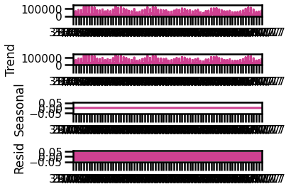

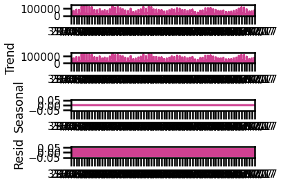

```python
#We can check the trend and seasonality using the  seasonal_decompose() method.
from statsmodels.tsa.seasonal import seasonal_decompose
decompose_result = seasonal_decompose(train_data,period=1)

decompose_result.plot()
```

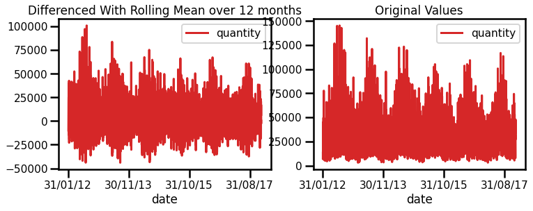

```python
#Trend is a pattern in data that shows the movement of a series to relatively
#higher or lower values over a long period of time

#removing trend using the rolling mean differencing

rolling_mean = train_data.rolling(window=12).mean()

#Rolling means creating a rolling window with
# a specified size and perform calculations on
# the data in this window which, of course, rolls through the data.

#Rolling averages are useful for finding long-term trends otherwise
# disguised by occasional fluctuations.
rolling_mean_detrended = train_data - rolling_mean

ax1 = plt.subplot(121)
rolling_mean_detrended.plot(figsize=(12,4),color="tab:red",
                            title="Differenced With Rolling Mean over 12 months",
                            ax=ax1)
ax2 = plt.subplot(122)
train_data.plot(figsize=(12,4),
          color="tab:red",
          title="Original Values",
          ax=ax2)
```

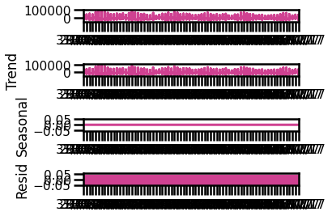

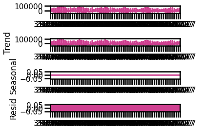

```python
from statsmodels.tsa.seasonal import seasonal_decompose
decompose_result = seasonal_decompose(rolling_mean_detrended.dropna(),period=1)
#We can check the trend and seasonality using the
# seasonal_decompose() method.
decompose_result.plot()


#Here in the  chart, we can see the decomposed
# structure of data and the structure of the components
#in the data set which were affecting it.
```

```python
rolling_mean_detrended
```

| date | quantity |
| --- | --- |
| 31/01/12 | NaN |
| 31/01/12 | NaN |
| 31/01/12 | NaN |
| 31/01/12 | NaN |
| 31/01/12 | NaN |
| ... | ... |
| 31/12/17 | 5596.416667 |
| 31/12/17 | 17185.083333 |
| 31/12/17 | 16350.750000 |
| 31/12/17 | -2842.250000 |
| 31/12/17 | 291.416667 |

6376 rows × 1 columns

```python
rolling_mean_detrended.shift(2).head(24)
```

| date | quantity |
| --- | --- |
| 31/01/12 | NaN |
| 31/01/12 | NaN |
| 31/01/12 | NaN |
| 31/01/12 | NaN |
| 31/01/12 | NaN |
| 31/01/12 | NaN |
| 31/01/12 | NaN |
| 31/01/12 | NaN |
| 31/01/12 | NaN |
| 31/01/12 | NaN |
| 31/01/12 | NaN |
| 31/01/12 | NaN |
| 31/01/12 | NaN |
| 31/01/12 | -9972.250000 |
| 31/01/12 | -3991.666667 |
| 31/01/12 | -8261.250000 |
| 31/01/12 | 693.166667 |
| 31/01/12 | 1211.000000 |
| 31/01/12 | 19562.166667 |
| 31/01/12 | 7631.500000 |
| 31/01/12 | 25303.333333 |
| 31/01/12 | -3623.333333 |
| 31/01/12 | -11167.750000 |
| 31/01/12 | 5885.083333 |

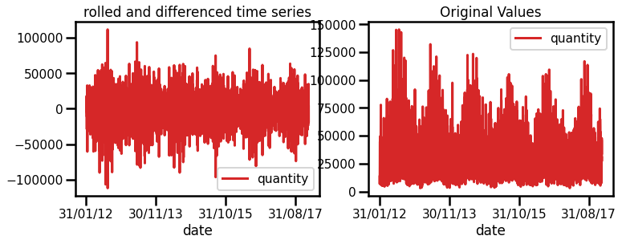

```python
#removing seasonality from the time series
rolling_mean_detrended_diff = rolling_mean_detrended - rolling_mean_detrended.shift()

ax1 = plt.subplot(121)
rolling_mean_detrended_diff.plot(figsize=(12,4),
                                 color="tab:red",
                                 title="rolled and differenced time series",
                                 ax=ax1)
ax2 = plt.subplot(122)
train_data.plot(figsize=(12,4),
          color="tab:red",
          title="Original Values",
          ax=ax2)
```

```python
rolling_mean_detrended_diff = rolling_mean_detrended_diff.dropna()
```

```python
rolling_mean_detrended_diff
```

| date | quantity |
| --- | --- |
| 31/01/12 | 5980.583333 |
| 31/01/12 | -4269.583333 |
| 31/01/12 | 8954.416667 |
| 31/01/12 | 517.833333 |
| 31/01/12 | 18351.166667 |
| ... | ... |
| 31/12/17 | -10192.416667 |
| 31/12/17 | 11588.666667 |
| 31/12/17 | -834.333333 |
| 31/12/17 | -19193.000000 |
| 31/12/17 | 3133.666667 |

6364 rows × 1 columns

```python
result = adfuller(rolling_mean_detrended_diff['quantity'].dropna())
#print(result)

print('ADF Statistic: %f' % result[0])
print('p-value: %f' % result[1])
print('Critical Values:')
for key, value in result[4].items():
	print('\t%s: %.3f' % (key, value))
```

```
ADF Statistic: -24.410119
p-value: 0.000000
Critical Values:
	1%: -3.431
	5%: -2.862
	10%: -2.567
```

# Final Thoughts on Autocorrelation and Partial Autocorrelation

Identification of an AR model is often best done with the PACF. For an AR model, the theoretical PACF “shuts off” past the order of the model. The phrase “shuts off” means that in theory the partial autocorrelations are equal to 0 beyond that point. Put another way, the number of non-zero partial autocorrelations gives the order of the AR model. By the “order of the model” we mean the most extreme lag of x that is used as a predictor. Identification of an MA model is often best done with the ACF rather than the PACF.

For an MA model, the theoretical PACF does not shut off, but instead tapers toward 0 in some manner. A clearer pattern for an MA model is in the ACF. The ACF will have non-zero autocorrelations only at lags involved in the model.

p,d,q p AR model lags d differencing q MA lags

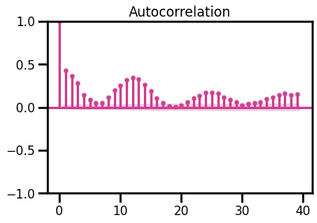

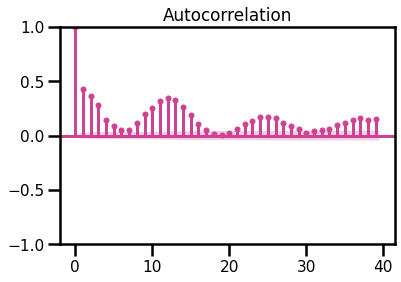

```python
from pandas.plotting import autocorrelation_plot
from statsmodels.graphics.tsaplots import plot_acf
#To check for the stationarity of the time series,
# statsmodels provides a plot_acf method to plot an autocorrelation plot.
plot_acf(train_data['quantity'])
```

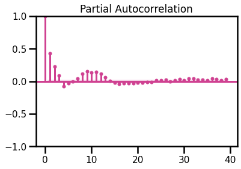

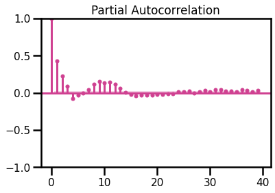

```python
from statsmodels.graphics.tsaplots import plot_pacf

plot_pacf(train_data['quantity'])
```

```python
!pip install pmdarima
from pmdarima import auto_arima
```

```python
ar=auto_arima(rolling_mean_detrended_diff['quantity'],trace=True)
ar.summary()
```

```
Performing stepwise search to minimize aic
 ARIMA(2,0,2)(0,0,0)[0] intercept   : AIC=inf, Time=4.31 sec
 ARIMA(0,0,0)(0,0,0)[0] intercept   : AIC=143039.548, Time=0.11 sec
 ARIMA(1,0,0)(0,0,0)[0] intercept   : AIC=141719.654, Time=0.23 sec
 ARIMA(0,0,1)(0,0,0)[0] intercept   : AIC=inf, Time=1.62 sec
 ARIMA(0,0,0)(0,0,0)[0]             : AIC=143037.548, Time=0.07 sec
 ARIMA(2,0,0)(0,0,0)[0] intercept   : AIC=141434.605, Time=0.37 sec
 ARIMA(3,0,0)(0,0,0)[0] intercept   : AIC=141429.350, Time=0.45 sec
 ARIMA(4,0,0)(0,0,0)[0] intercept   : AIC=141387.563, Time=0.52 sec
 ARIMA(5,0,0)(0,0,0)[0] intercept   : AIC=141322.657, Time=0.63 sec
 ARIMA(5,0,1)(0,0,0)[0] intercept   : AIC=inf, Time=7.77 sec
 ARIMA(4,0,1)(0,0,0)[0] intercept   : AIC=inf, Time=6.82 sec
 ARIMA(5,0,0)(0,0,0)[0]             : AIC=141320.656, Time=0.35 sec
 ARIMA(4,0,0)(0,0,0)[0]             : AIC=141385.563, Time=0.28 sec
 ARIMA(5,0,1)(0,0,0)[0]             : AIC=inf, Time=5.06 sec
 ARIMA(4,0,1)(0,0,0)[0]             : AIC=inf, Time=3.63 sec

Best model:  ARIMA(5,0,0)(0,0,0)[0]
Total fit time: 32.293 seconds
```

SARIMAX Results

| Dep. Variable: | y | No. Observations: | 6364 |
| --- | --- | --- | --- |
| Model: | SARIMAX(5, 0, 0) | Log Likelihood | -70654.328 |
| Date: | Thu, 05 Jan 2023 | AIC | 141320.656 |
| Time: | 12:21:42 | BIC | 141361.207 |
| Sample: | 0 | HQIC | 141334.696 |
|  | - 6364 |  |  |
| Covariance Type: | opg |  |  |

|  | coef | std err | z | P>\|z\| | [0.025 | 0.975] |
| --- | --- | --- | --- | --- | --- | --- |
| ar.L1 | -0.5423 | 0.009 | -58.444 | 0.000 | -0.561 | -0.524 |
| ar.L2 | -0.2544 | 0.012 | -20.833 | 0.000 | -0.278 | -0.230 |
| ar.L3 | -0.1029 | 0.012 | -8.442 | 0.000 | -0.127 | -0.079 |
| ar.L4 | -0.1374 | 0.013 | -10.675 | 0.000 | -0.163 | -0.112 |
| ar.L5 | -0.1023 | 0.012 | -8.576 | 0.000 | -0.126 | -0.079 |
| sigma2 | 2.576e+08 | 1.05e-11 | 2.45e+19 | 0.000 | 2.58e+08 | 2.58e+08 |

| Ljung-Box (L1) (Q): | 1.31 | Jarque-Bera (JB): | 790.03 |
| --- | --- | --- | --- |
| Prob(Q): | 0.25 | Prob(JB): | 0.00 |
| Heteroskedasticity (H): | 0.65 | Skew: | 0.24 |
| Prob(H) (two-sided): | 0.00 | Kurtosis: | 4.66 |

Warnings:  
[1] Covariance matrix calculated using the outer product of gradients (complex-step).  
[2] Covariance matrix is singular or near-singular, with condition number 1.8e+34. Standard errors may be unstable.

```python
from statsmodels.tsa.statespace.sarimax import SARIMAX, SARIMAXResults

model = SARIMAX(train_data, order=(5,0,0), seasonal_order=(5,0,0,12))
model = model.fit()
```

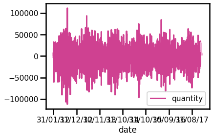

```python
forecast = model.forecast(steps=60)
rolling_mean_detrended_diff.plot()
forecast.plot()
```

```python
pip install statsmodels
```

```python
import numpy as np
from sklearn.model_selection import TimeSeriesSplit
X = rolling_mean_detrended_diff.iloc[:4454]['quantity']
y = rolling_mean_detrended_diff.iloc[4455:]['quantity']
tscv = TimeSeriesSplit()
print(tscv)
TimeSeriesSplit(max_train_size=None, n_splits=3)
for train_index, test_index in tscv.split(X):
    print("TRAIN:", train_index, "TEST:", test_index)
    X_train, X_test = X[train_index], X[test_index]
    y_train, y_test = y[train_index], y[test_index]
```

[output not shown]

[output cut: 133 more lines]

[output not shown]

[output cut: 18 more lines]

[output not shown]

```python
from sklearn.model_selection import TimeSeriesSplit
from sklearn.metrics import mean_squared_error
import statsmodels.api as sm
sm.tsa.ARIMA(rolling_mean_detrended_diff['quantity'],order=(5,0,5))
tscv = TimeSeriesSplit(n_splits = 4)
rmse = []
for train_index, test_index in tscv.split(cross_validation):
    cv_train, cv_test = cross_validation.iloc[train_index], cross_validation.iloc[test_index]

    arima = sm.tsa.ARIMA(cv_train, (2,2)).fit(disp=False)

    predictions = arima.predict(cv_test.index.values[0], cv_test.index.values[-1])
    true_values = cv_test.values
    rmse.append(sqrt(mean_squared_error(true_values, predictions)))

print("RMSE: {}".format(np.mean(rmse)))
```

[output not shown]